# Refinements to Rceattle for eastern Bering Sea pollock

Working paper on 2024 PM model refinements

Authors

Affiliation

James Ianelli

Alaska Fisheries Science Center

Grant Adams

Published

August 10, 2026

Abstract

The custom ADMB stock assessment model developed for eastern Bering Sea walleye pollock has a long history of application. For a variety of reasons, including general recommendations from the 2025 CIE reviews, the custom ADMB code has been successfully ported to RTMB. That conversion provides access to advanced RTMB features and makes the underlying code easier to understand and modify. Similarly, adopting more generic platforms, such as Rceattle, can provide access to more modern software developments. In this study, we tailored Rceattle code and configurations so that Rceattle can closely mimic the custom ADMB/RTMB assessment code. For example, we added a non-parametric selectivity form as an option within Rceattle. We also introduced a two-dimensional AR1 selectivity form, which we consider a reasonable alternative for further evaluation.

## 1 Executive Summary

Building from the ADMB-to-RTMB conversion, this analysis evaluates whether Rceattle can be configured to reproduce the main features of the 2024 eastern Bering Sea pollock PM assessment while providing a more general and extensible modeling framework. Grant Adams’s initial Rceattle developments provided the starting point for this evaluation, including the 2024 model-input workbook, two-stage NonParametricPM configuration, diagnostic scripts, an annual data-update template, a DSEM recruitment example, and ADMB comparison calculations. The focus here is on refinements to Rceattle and their agreement with the custom ADMB/RTMB assessment, rather than on a new stock assessment or harvest specification.

An initial step in comparing model behavior between Rceattle and the ADMB pollock assessment model was to apply the ADMB parameter estimates and fishery selectivity-at-age in Rceattle and compare the resulting output. Rceattle reproduces numbers-at-age, spawning biomass, and predicted catch to rounding-scale precision. Mean absolute differences are 0.000117% for spawning biomass and 0.000143% for predicted catch.

When we configured Rceattle to use a non-parametric constrained selectivity form, it tracked the slightly modified ADMB model very well. In 2024, the differences were -0.2% for spawning biomass, -0.9% for recruitment, and -0.2% for total biomass. The largest differences occurred early in the time series and were linked to weak identification of initial abundance and fishery-selectivity scale.

The 2D age-by-year AR1 selectivity sensitivity was included as an initial diagnostic attempt. Results appeared broadly similar to the non-parametric constrained selectivity fits. However, because some parameters reached bounds, the model failed to converge. Closer examination of this selectivity form will continue as a research topic.

OSA residuals have been generated on the current Rceattle main branch. They are useful for the September 2026 review, but they do not yet form a complete diagnostic package. Aggregate residual dispersion is lower than expected, and several analytically solved or exactly reproduced index groups return zero residual dispersion. Retrospectives, jitters, self-tests, and a likelihood profile remain pending.

**Important**

This is a methods working paper for the September 2026 Plan Team evaluations. It does not update the operational assessment, stock status, ABC, OFL, or harvest recommendation.

The exploratory Bayesian work remains separate in the SparseNUTS companion report.

## 2 Purpose and Scope

The main question for September 2026 is not whether this document resembles a full SAFE chapter. The relevant question is whether the Rceattle configuration is documented well enough for Plan Team review.

This working paper therefore records:

- what was run from those development files;
- how the Rceattle outputs compare with the modified ADMB reference;
- which diagnostics are available now;
- which diagnostics remain unfinished; and
- what decisions or requests would help structure the next evaluation pass.

Standard SAFE report sections such as background material, fishery history, ecosystem narrative, reference-point tables, projections, and harvest advice are outside the scope of this document.

## 3 Initial Rceattle Developments

Table 1: Disposition of the initial Rceattle development components.

| Item | Initial_development | September_review_result | Plan_Team_interpretation |
| --- | --- | --- | --- |
| 1 | Prepared Rceattle model-input workbook | Used the delivered workbook directly. | Input files are available and reproducible from stored files. |
| 2 | Main two-stage fit and 2D AR1 sensitivity | Two-stage NonParametricPM completed; 2D AR1 failed convergence checks. | The NonParametricPM configuration is the relevant Rceattle comparison; 2D AR1 is diagnostic only. |
| 3 | Convergence and model diagnostics | Structured convergence checks and OSA diagnostics are saved. | Retrospectives, jitters, self-tests, and profiles remain pending. |
| 4 | Next-assessment data update workflow | Update script was reviewed but not run with placeholder data. | Useful as a template only after complete new-year observations are inserted. |
| 5 | DSEM recruitment example | Script was reviewed against the ESP cohort-table workflow but not run. | Placeholder covariates should be replaced with cohort-aligned ESP indicators before fitting. |
| 6 | ADMB-to-Rceattle comparison diagnostics | The ADMB-parameter comparison reproduces ADMB to rounding-scale precision. | This is the strongest evidence that the ADMB comparison is correct. |

### 3.1 Model Inputs

The Rceattle configuration uses the prepared workbook `Data/2024_EBS_pollock_m23_rceattle_full.xlsx`. That workbook contains the 2024 assessment data, BTS survey covariance input, and settings needed to align the Rceattle configuration with the modified ADMB model. The workbook was accepted as a delivered model-input artifact rather than rebuilt in this pass.

The next-assessment update script was reviewed but not executed. It duplicates terminal records and places placeholders for new catch, composition, and survey observations. Running it before replacing those placeholders would create an incomplete assessment workbook, so it is best treated as a template until complete new-year observations are available.

### 3.2 Selectivity specifications

#### 3.2.1 Non-parametric selectivity

The primary independently fitted comparison is the two-stage NonParametricPM fit. The initial analysis uses an empirical fishery selectivity start because the fishery selectivity likelihood is multimodal. The fit sequence is:

1. turn time-varying selectivity deviations off to establish the selectivity and abundance scale; and
2. enable the deviations and initialize the full fit from the first stage.

This approach completed and produced close agreement with ADMB. The final fit is not a clean `OK`, however. It has a `WARN` convergence status because the Hessian condition number is high and the least-identified direction loads almost entirely on `sel_coff_dev`.

#### 3.2.2 2D-AR1 selectivity

The 2D AR1 sensitivity was configured only for the fishery selectivity block, which was also used by the CPUE index through the shared `Selectivity_index`. Other fleet selectivity forms were left in their existing configurations. The fishery and CPUE rows were set to `Selectivity = "2DAR1"`, with `Time_varying_sel = "Off"` because the 2D AR1 field provides the age-year variation directly. The field covered 12 selectivity bins beginning at age 1 and 61 years (1964-2024).

Core assessment parameters were optimized, but the 2D AR1 selectivity change was limited to the shared fishery/CPUE block. Within that block, the base selectivity coefficients, year correlation, age correlation, and deviation scale were active fixed-effect parameters. The age-year deviations were first tested as penalized fixed effects (`random_sel = FALSE`) to obtain a non-zero field. The final sensitivity then used `random_sel = TRUE`, so the age-year deviations were treated as random effects and integrated with the Laplace approximation. The estimated correlations and scale are shown in Table 2.

Table 2: Estimated 2D AR1 fishery-selectivity correlation and scale parameters.

| Quantity | Rceattle parameter | Penalized fixed effects | Final random effects | Final internal value |
| --- | --- | --- | --- | --- |
| Year AR1 correlation | Sel_curve_pen1 | 0.584 | 0.947 | 3.600 |
| Age AR1 correlation | Sel_curve_pen2 | 0.120 | 0.098 | 0.197 |
| Selectivity deviation scale | sel_dev_log_sd | 0.500 | 0.379 | −0.969 |

Correlation parameters are shown on the transformed -1 to 1 scale; final internal values are logit-scale for correlations and log-scale for the selectivity deviation scale.

The final random-effects run estimated the year correlation at 0.947, the age correlation at 0.098, and the selectivity-deviation scale at 0.379. These values should be interpreted only as diagnostic estimates because the final result failed convergence checks:

- maximum marginal gradient: 17.8, largest on `rec_pars`;
- Hessian not invertible, so standard errors are unavailable;
- 56 `log_F` parameters at configured bounds; and
- final convergence status: `FAIL`.

The terminal biomass values remained near ADMB, and the results were similar enough to warrant further evaluation. However, the historical trajectory differences and failed convergence checks mean that closer examination of this selectivity form should continue as a research topic.

The three specifications are compared directly in Figure 1. The ADMB reference and fitted NonParametricPM curves are the relevant bridge comparison; the 2D-AR1 curves are retained only to show the behavior of the failed sensitivity.

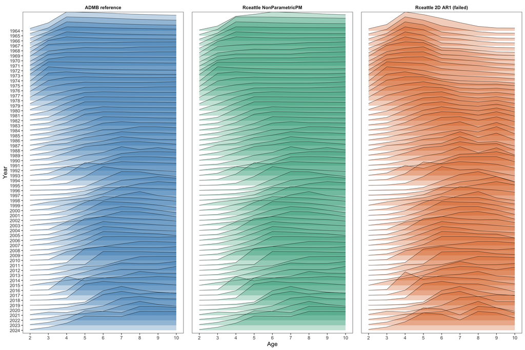

Figure 1: Relative fishery selectivity by year for the modified ADMB reference, fitted Rceattle NonParametricPM model, and Rceattle 2D age-by-year AR1 sensitivity. Each annual curve is normalized to a maximum of one. The 2D-AR1 panel is shown as a diagnostic comparison only because that fit failed convergence checks.

### 3.3 DSEM Example

The DSEM example was reviewed but not run. It requires `grantdadams/Rceattle@dev-DSEM` and `dsem` version 3.0.0. It also changes recruitment deviations from penalized fixed effects to random effects (`random_rec = TRUE`) because the dynamic structural equation model treats recruitment deviations as a stochastic process. The current script compares an environment-free IID recruitment-deviation model with an environment-linked SEM, but the environmental columns are random placeholders (`BottomTemp`, `ColdPool`, and `SST`). Those placeholders should not be used for an assessment result.

The implementation should instead use the [ESP early-survival pathway synthesis](https://afsc-assessments.github.io/ebswp_esp/) as the covariate-selection and data-assembly framework. That synthesis identifies two primary prerecruit filters for EBS pollock: an age-0 energy and condition filter before winter, and an age-1 to age-2 predation/overlap filter before age-3 recruitment. Transport and nursery-delivery processes remain useful supporting hypotheses where spawning-location, larval-transport, prey-match, and age-0 abundance products are available.

The basic testing DAG in Figure 2 translates those pathways into a small set of cohort-aligned hypotheses. Arrows state the assumed direction of influence to be tested; they do not establish that the relationships are causal or that every displayed path should be fitted simultaneously.

```
flowchart LR
  SSB["Spawning biomass (t)"] --> EGG["Egg production (t)"]
  EGG --> AGE0["Age-0 abundance and condition (t)"]

  ICE["Ice retreat (t)"] --> AGE0
  SST["Late-summer temperature (t)"] --> AGE0
  PREY["Copepods and euphausiids (t)"] --> AGE0
  TRANS["Transport and nursery delivery (t)"] -. later extension .-> AGE0

  AGE0 --> SURV0["Age-0 to age-1 survival"]
  SURV0 --> REC["Age-3 recruitment (t+3)"]

  COLD["Cold-pool extent (t+1)"] --> OVERLAP["Juvenile-predator overlap (t+1)"]
  PRED["Predator biomass (t+1)"] --> OVERLAP
  ADULT["Adult pollock biomass (t+1)"] --> OVERLAP
  OVERLAP --> SURV12["Age-1 to age-2 survival"]
  SURV12 --> REC

  classDef state fill:#e8f3f8,stroke:#176b87,color:#102a33;
  classDef env fill:#f7f1dc,stroke:#9a7617,color:#332707;
  classDef outcome fill:#e8f4e8,stroke:#397a3f,color:#17331a;
  class SSB,EGG,AGE0,SURV0,OVERLAP,SURV12 state;
  class ICE,SST,PREY,TRANS,COLD,PRED,ADULT env;
  class REC outcome;
```

Figure 2: Basic cohort-aligned DAG for initial Rceattle DSEM recruitment tests. Subscripts identify the cohort’s age-0 year (t), following age-1 year (t+1), and age-3 recruitment year (t+3). Solid pathways define the two initial prerecruit hypotheses; the transport pathway is retained as a later extension because its supporting data are less complete.

For a first DSEM evaluation, the two branches in Figure 2 should be fitted separately before considering the reduced integrated-gate model. This makes it possible to diagnose whether any improvement comes from the age-0 condition hypothesis, the age-1/2 overlap hypothesis, or an unsupported combination of correlated indicators.

The practical implementation would start from a cohort-aligned input table with one row per year class. The ESP workflow uses suffixes to make timing explicit: `_t` for the cohort’s age-0/spawning year, `_t1` for the following age-1 year, and `_t3` for age-3 recruitment. Candidate fields include spawning biomass, ice retreat, late-summer SST, wind mixing, copepod/euphausiid biomass, age-0 energy, cold-pool extent, age-1 abundance, adult pollock biomass, arrowtooth biomass, juvenile-predator overlap, and age-3 recruitment. For the Rceattle script, those cohort-aligned columns should replace the random `env_data` values after confirming whether the modeled recruitment response is the assessment’s age-1 recruitment deviation, an age-3 recruitment index, or a documented transformation between the two.

The first Rceattle DSEM tests should be small and hypothesis-specific. The recommended sequence is:

1. fit the environment-free IID recruitment-deviation model as the baseline;
2. fit an age-0 condition model using the best-supported energy or condition indicator;
3. fit a predator-overlap model using adult pollock biomass, predator biomass, cold-pool extent, and a juvenile-predator overlap index;
4. fit a reduced integrated-gate model with one representative age-0 condition indicator and one representative predation/overlap indicator; and
5. reserve the transport/nursery-delivery model until the required spawning-location, particle-tracking, prey-match, and age-0 abundance products are available.

Each DSEM result should be compared with the IID baseline using AIC, standardized path coefficients, convergence status, and sensitivity to alternative proxies and influential year classes. This keeps the DSEM work tied to the ESP biological hypotheses while avoiding an unrestricted environmental screen with weakly identified annual series.

## 4 ADMB Comparison Results

The initial comparison analysis contains two comparisons.

The first comparison applied the ADMB parameter estimates and fishery selectivity-at-age in Rceattle and compared the resulting output with the ADMB pollock assessment model. This checks whether the same estimates produce the same derived quantities. The agreement is effectively exact.

The two-stage NonParametricPM fit is an optimization and model-behavior test. It estimates the Rceattle model independently and asks whether the optimizer reaches a scientifically similar solution.

Table 3: ADMB-parameter comparison summary.

| Metric | Value |
| --- | --- |
| N ratio minimum | 0.999993 |
| N ratio maximum | 1.000006 |
| SSB ratio minimum | 0.999997 |
| SSB ratio maximum | 1.000003 |
| SSB mean absolute percent difference | 0.000117 |
| Catch mean absolute percent difference | 0.000143 |

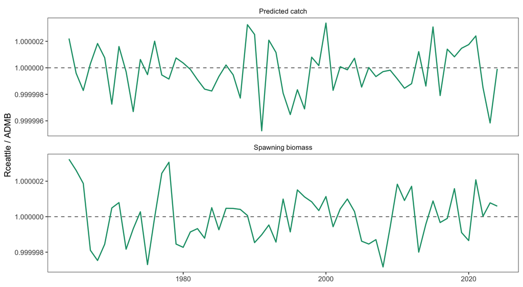

Figure 3: Fixed-parameter Rceattle-to-ADMB ratios for spawning biomass and predicted catch.

Table 4: Agreement between fitted Rceattle trajectories and the modified ADMB reference.

| Quantity | Correlation | Mean \|% difference\| | Maximum \|% difference\| | 2024 % difference |
| --- | --- | --- | --- | --- |
| NonParametricPM |  |  |  |  |
| SSB | 1.00 | 1.30 | 10.00 | −0.20 |
| Recruitment | 1.00 | 0.30 | 2.00 | −0.90 |
| Biomass | 1.00 | 1.00 | 8.80 | −0.20 |
| 2D AR1 |  |  |  |  |
| SSB | 0.98 | 16.70 | 70.30 | −2.00 |
| Recruitment | 1.00 | 6.40 | 18.00 | −1.90 |
| Biomass | 0.96 | 13.50 | 65.20 | −1.30 |

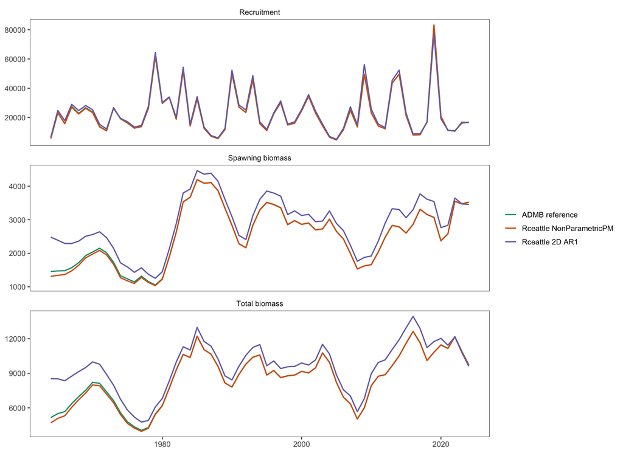

Figure 4: ADMB reference and Rceattle trajectories for the fitted NonParametricPM configuration and failed 2D AR1 sensitivity.

The fitted NonParametricPM configuration is closest after the early period. The spawning-biomass difference from ADMB is -10.0% in 1964, -2.4% in 1978, -0.1% in 1990, -0.1% in 2008, and -0.2% in 2024. Recruitment and total biomass show the same pattern of close agreement in modern assessment years.

## 5 Diagnostics

Table 5: Stored Rceattle convergence checks for the evaluated configurations.

| Model | Status | Objective | Max gradient | Worst parameter | Positive definite Hessian | Warnings or failures |
| --- | --- | --- | --- | --- | --- | --- |
| Stage 1 scale fit | OK | 1,960.545522 | 0.000382 | rec_pars | TRUE | None |
| Two-stage NonParametricPM | WARN | 713.676499 | 0.000044 | sel_coff_dev | TRUE | Hessian condition number = 1.2e+06. Least-identified direction loads on: sel_coff_dev (100%). |
| 2D AR1 selectivity sensitivity | FAIL | 1,270.801558 | 17.771505 | rec_pars | NA | Phase(s) ended with max\|grad\| > 1: phase 4 (34), phase 5 (93).; Maximum absolute marginal gradient = 17.8 (largest on 'rec_pars').; sdreport failed (Hessian not invertible); standard errors unavaila… |

The base Rceattle configuration has acceptable gradients and a positive definite Hessian, but the Hessian-conditioning warning is substantive. It says the remaining weak direction is almost entirely in the time-varying fishery selectivity coefficients. That is a diagnostic issue to resolve or clearly bound before this fit is promoted from comparison evidence to an operational assessment candidate.

Table 6: Diagnostic status for the September 2026 review.

| Diagnostic | Current_status | Use_for_September_2026_review |
| --- | --- | --- |
| ADMB-parameter comparison | Completed and saved in fixed-parameter comparison outputs. | Primary numerical agreement check. |
| Two-stage NonParametricPM fit | Completed with WARN status from Hessian conditioning. | Primary independently fitted Rceattle comparison. |
| 2D AR1 selectivity sensitivity | Failed convergence, Hessian inversion, and bound checks. | Requires further research before it can be considered as an alternative selectivity form. |
| OSA residuals | Completed for 1,864 residuals and saved in RDS outputs. | Useful, but analytical and exactly reproduced index groups need interpretation. |
| Rceattle retrospectives | Not run in this pass. | Needed before an operational model update claim. |
| Legacy ADMB retrospectives | Existing ADMB retro.rep files are present. | Context only; not a substitute for Rceattle retrospective peels. |
| Jitters, self-tests, and likelihood profile | Not run in this pass. | Needed to complete a full diagnostics package. |
| DSEM recruitment example | Not run in this pass. | Exploratory only; implementation should use cohort-aligned ESP indicators rather than placeholder covariates. |

### 5.1 OSA Residuals

OSA residuals now run on the installed Rceattle main branch; the development branch identified in the original materials is no longer required for this operation. A total of 1864 OSA residuals were generated.

Table 7: OSA residual dispersion and tail diagnostics.

| Data group | n | SDNR | Expected lower | Expected upper | Lower tail | Upper tail | All checks pass |
| --- | --- | --- | --- | --- | --- | --- | --- |
| Fishery catch | 61 | 0.311 | 0.821 | 1.178 | −0.866 | 0.557 | FALSE |
| Fishery comp | 840 | 0.639 | 0.952 | 1.048 | −1.351 | 1.368 | FALSE |
| AVO index | 18 | 0.000 | 0.667 | 1.333 | 0.000 | 0.000 | FALSE |
| BTS comp | 588 | 0.802 | 0.943 | 1.057 | −1.794 | 1.632 | FALSE |
| BTS index | 42 | 0.000 | 0.784 | 1.215 | 0.000 | 0.000 | FALSE |
| ATS comp | 266 | 0.517 | 0.915 | 1.085 | −1.030 | 0.947 | FALSE |
| ATS index | 19 | 0.992 | 0.676 | 1.323 | −1.648 | 1.467 | TRUE |
| ATS_1 index | 18 | 1.139 | 0.667 | 1.333 | −1.672 | 2.109 | TRUE |
| CPUE index | 12 | 0.000 | 0.589 | 1.412 | 0.000 | 0.000 | FALSE |
| All residuals | 1864 | 0.673 | 0.968 | 1.032 | −1.457 | 1.402 | FALSE |

The aggregate SDNR is 0.673, below its expected interval of 0.968–1.032. ATS index residuals have SDNR 0.992 and ATS age-1 index residuals have SDNR 1.139; both pass the SDNR and tail checks. Fishery, BTS, and ATS composition groups are underdispersed relative to the OSA reference.

AVO, BTS index, and CPUE groups return zero residual dispersion in this run. These cases include analytical or exactly reproduced index components and should not be read as conventional evidence of a perfect observation model. They warrant checking whether the current OSA construction is informative for analytically solved catchability and MVN index components.

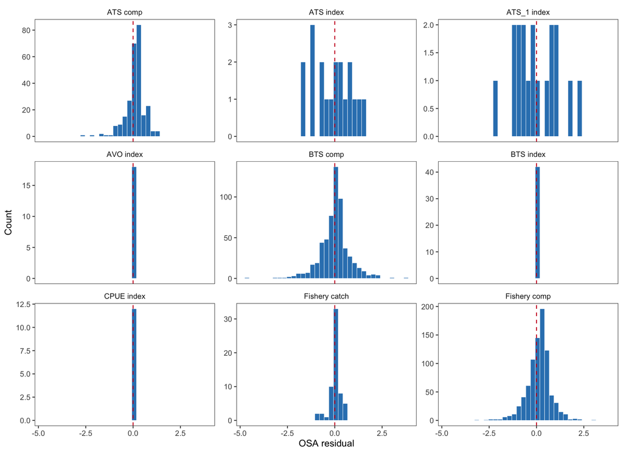

Figure 5: OSA residual distributions by source and fleet.

### 5.2 Retrospectives and Remaining Diagnostics

The full Rceattle diagnostic batch was not run in this pass. That batch should include five retrospective peels and Mohn’s rho, a controlled jitter set, self-test simulations, and a likelihood profile for natural mortality.

Legacy ADMB retrospective files are present and useful as context, but they should not be substituted for Rceattle retrospective peels. A September 2026 evaluation can use the ADMB retrospectives to understand the historical assessment behavior, while still requesting a dedicated Rceattle retrospective batch before any operational model-change decision.

## 6 September 2026 Evaluation Questions

The initial Rceattle development work narrows the Plan Team discussion to a few concrete questions:

- Does the ADMB-parameter comparison establish sufficient numerical agreement for the Rceattle population dynamics and likelihood components tested here?
- Is the two-stage NonParametricPM configuration close enough to ADMB to serve as the basis for a broader Rceattle diagnostic package?
- What additional evidence is required to resolve or bound the fishery-selectivity scale weakness indicated by the Hessian conditioning warning?
- Should the failed 2D AR1 selectivity sensitivity be dropped, redesigned, or retained only as a record of an unsuccessful sensitivity?
- How should OSA diagnostics be interpreted for analytical or exactly reproduced index components that return zero residual dispersion?
- What acceptance criteria should be set for the next-assessment update workbook before it is used operationally?
- Should DSEM recruitment work proceed only after the Plan Team identifies defensible EBS environmental covariates and a branch or release strategy for Rceattle?

## 7 Conclusions and Next Work

The initial development work achieved its primary purpose. The fixed-parameter Rceattle calculation reproduces the modified 2024 PM ADMB assessment to rounding-scale precision. The independently fitted NonParametricPM Rceattle configuration remains a close, but not exact, optimization match. The main unresolved issue is weak identification of selectivity and scale, not evidence that the ADMB-parameter comparison is wrong.

Recommended next work is:

1. run and save the five-peel Rceattle retrospective batch;
2. run a small jitter pilot before committing to the full jitter set;
3. investigate zero-dispersion OSA groups for analytical and MVN index components;
4. retain the ADMB-parameter comparison as a quality-control comparison after package, likelihood, or data changes;
5. populate the next-assessment workbook only after complete new-year observations are available; and
6. select and document environmental covariates before running the DSEM recruitment example.

## 8 Reproducibility

Table 8: Files used or referenced by this working paper.

| Role | Location | Available | Size |
| --- | --- | --- | --- |
| SparseNUTS companion report | Local HTML copy | TRUE | 8610.8 KB |
| Prepared model-input workbook | Local workbook | TRUE | 128.5 KB |
| BTS covariance input | Local data file | TRUE | 12.7 KB |
| Saved fitted Rceattle objects | Local RDS | TRUE | 63598.3 KB |
| OSA residuals | Local RDS | TRUE | 90.0 KB |
| OSA diagnostics | Local RDS | TRUE | 1.0 KB |
| Fixed-parameter comparison output | Local RDS | TRUE | 646.2 KB |
| Fixed-parameter comparison summary | Local CSV | TRUE | 0.3 KB |
| Two-stage fit script | Local R script | TRUE | 15.4 KB |
| Diagnostics script | Local R script | TRUE | 4.9 KB |
| Next-assessment update script | Local R script | TRUE | 2.6 KB |
| DSEM example script | Local R script | TRUE | 5.1 KB |
| ADMB comparison script | Local R script | TRUE | 9.5 KB |
| Modified ADMB retrospective file | Local ADMB output | TRUE | 0.0 KB |
| Legacy ADMB retrospective file | Local ADMB output | TRUE | 0.0 KB |